# Final project: Rolling Stones

Flora Janku

## Research problem

Listening to music is an important aspect of humans’ lives. It is not only considered a favourable pastime activity, but also as a means to regulate our emotions and mood, and express thoughts and feelings that otherwise may be difficult to put into words (https://www.frontiersin.org/journals/psychology/articles/10.3389/fpsyg.2017.00501/full).

With the rise of the music industry in the first half of the 1900’s, business has started to sail, and the need for an evaluation of the success of a musical piece has risen. The Rolling Stone, one of the most prestigious music magazines, was created in 1967, with a focus on rock music. Later, it has widened its scope on all music genres. In 2003, the Rolling Stone released its first ever list of ‘The 500 Greatest Albums of All Time’, where musicians, critics and music industry figures voted on the 500 best albums ever released (https://www.rollingstone.com/music/music-lists/best-songs-of-all-time-1224767/). The list has since been revised twice, once in 2012 and another time in 2020.

Since the list sets out to rank the 500 greatest albums of all time, it becomes interesting to explore what aspects of an album contribute to a rank in the Top 500 Greatest Albums. According to a visual essay on the Rolling Stone’s Billboard 500 (https://pudding.cool/2024/03/greatest-music/), in 2003 and 2012, almost no changes occurred in the top 10 albums, whereas in 2020, almost the entire top 10 was different than before. Therefore, there must be aspects that have changed over time, that influenced whether an album received a ranking in 2020, compared to 2012 or 2003.

## Research question and hypotheses

My research question is: what aspects of an album contributed to a rank on the 2020 Rolling Stones’ ‘The 500 Greatest Albums of All Time’?

I hypothesize that such a factor was Spotify popularity, which was more influential in 2020 compared to 2012 or 2003. Other than Spotify popularity, I will test weeks spent on Billboard, years between debut and top 500 ranking, release year and album type as predictors of a top 500 ranking in 2020.

I will also investigate in a separate ANOVA test whether album type influenced ranking in 2020, since according to the visual essay, the popularity of Greatest Hits and Compilation albums decreased over time.

Finally, the relationship of ranking differential between 2020-2003 and album type will be investigated. I hypothesize that album type did not effect the ranking in 2020, but it influenced the ranking differential (the change in positions between the 2020 list and the 2003 list) over time.

```r
knitr::opts_chunk$set(echo = TRUE)
library(tidyverse)
library(performance)
library(AICcmodavg)
library(stats)
library(car)
theme_set(theme_light())
```

## Read data

```r
rolling_stone <- readr::read_csv('https://raw.githubusercontent.com/rfordatascience/tidytuesday/master/data/2024/2024-05-07/rolling_stone.csv')
```

# Check structure of the dataset

```r
#Explore dataset
head(rolling_stone)
```

```
## # A tibble: 6 × 21
##   sort_name      clean_name     album rank_2003 rank_2012 rank_2020 differential
##   <chr>          <chr>          <chr>     <dbl>     <dbl>     <dbl>        <dbl>
## 1 Sinatra, Frank Frank Sinatra  In t…       100       101       282         -182
## 2 Diddley, Bo    Bo Diddley     Bo D…       214       216       455         -241
## 3 Presley, Elvis Elvis Presley  Elvi…        55        56       332         -277
## 4 Sinatra, Frank Frank Sinatra  Song…       306       308        NA         -195
## 5 Little Richard Little Richard Here…        50        50       227         -177
## 6 Beyonce        Beyonce        Lemo…        NA        NA        32          469
## # ℹ 14 more variables: release_year <dbl>, genre <chr>, type <chr>,
## #   weeks_on_billboard <dbl>, peak_billboard_position <dbl>,
## #   spotify_popularity <dbl>, spotify_url <chr>, artist_member_count <dbl>,
## #   artist_gender <chr>, artist_birth_year_sum <dbl>,
## #   debut_album_release_year <dbl>, ave_age_at_top_500 <dbl>,
## #   years_between <dbl>, album_id <chr>
```

```r
dim(rolling_stone)
```

```
## [1] 691  21
```

```r
summary(rolling_stone)
```

```
##   sort_name          clean_name           album             rank_2003
##  Length:691         Length:691         Length:691         Min.   :  1.0
##  Class :character   Class :character   Class :character   1st Qu.:125.8
##  Mode  :character   Mode  :character   Mode  :character   Median :250.5
##                                                           Mean   :250.5
##                                                           3rd Qu.:375.2
##                                                           Max.   :500.0
##                                                           NA's   :191
##    rank_2012       rank_2020      differential      release_year
##  Min.   :  1.0   Min.   :  1.0   Min.   :-501.00   Min.   :1955
##  1st Qu.:125.8   1st Qu.:125.8   1st Qu.:-137.50   1st Qu.:1971
##  Median :250.5   Median :250.5   Median :  -8.00   Median :1979
##  Mean   :250.5   Mean   :250.5   Mean   : -12.32   Mean   :1983
##  3rd Qu.:375.2   3rd Qu.:375.2   3rd Qu.: 106.00   3rd Qu.:1994
##  Max.   :500.0   Max.   :500.0   Max.   : 484.00   Max.   :2019
##  NA's   :191     NA's   :191
##     genre               type           weeks_on_billboard
##  Length:691         Length:691         Min.   :  1.00
##  Class :character   Class :character   1st Qu.: 20.75
##  Mode  :character   Mode  :character   Median : 44.50
##                                        Mean   : 64.27
##                                        3rd Qu.: 81.00
##                                        Max.   :741.00
##                                        NA's   :119
##  peak_billboard_position spotify_popularity spotify_url
##  Min.   :  1.00          Min.   :10.00      Length:691
##  1st Qu.:  2.00          1st Qu.:46.00      Class :character
##  Median : 17.00          Median :57.00      Mode  :character
##  Mean   : 61.19          Mean   :55.81
##  3rd Qu.:111.50          3rd Qu.:68.00
##  Max.   :201.00          Max.   :91.00
##                          NA's   :37
##  artist_member_count artist_gender      artist_birth_year_sum
##  Min.   : 1.000      Length:691         Min.   : 1910
##  1st Qu.: 1.000      Class :character   1st Qu.: 1948
##  Median : 2.000      Mode  :character   Median : 3896
##  Mean   : 2.746                         Mean   : 5363
##  3rd Qu.: 4.000                         3rd Qu.: 7845
##  Max.   :12.000                         Max.   :23368
##  NA's   :5                              NA's   :5
##  debut_album_release_year ave_age_at_top_500 years_between
##  Min.   :1934             Min.   :17.00      Min.   : 0.000
##  1st Qu.:1966             1st Qu.:24.04      1st Qu.: 1.000
##  Median :1973             Median :27.00      Median : 3.000
##  Mean   :1977             Mean   :29.61      Mean   : 5.929
##  3rd Qu.:1989             3rd Qu.:31.00      3rd Qu.: 7.000
##  Max.   :2019             Max.   :88.00      Max.   :54.000
##  NA's   :5                NA's   :5          NA's   :5
##    album_id
##  Length:691
##  Class :character
##  Mode  :character
##
##
##
##
```

```r
#There are no duplicates
rolling_stone %>%
  count(album_id, sort = TRUE)
```

```
## # A tibble: 691 × 2
##    album_id                   n
##    <chr>                  <int>
##  1 01TG7VOg4F90jXv3a1yCgA     1
##  2 01uTaEF0YlcBgNwaSS9iIl     1
##  3 02XyFDfvHfIwtqOC3o0PcK     1
##  4 03GKkfyog7hnllilFS3jIV     1
##  5 03zfU3IwWmymKoaWnwFNaY     1
##  6 04FfqGvZJ9oUBGRVrq2FE5     1
##  7 04VRfesff9bgDA2Q8J2oDo     1
##  8 05n0d2kfwGPhKpTonLHRpY     1
##  9 097eYvf9NKjFnv4xA9s2oV     1
## 10 09AwlP99cHfKVNKv4FC8VW     1
## # ℹ 681 more rows
```

```r
#Check variables
glimpse(rolling_stone)
```

```
## Rows: 691
## Columns: 21
## $ sort_name                <chr> "Sinatra, Frank", "Diddley, Bo", "Presley, El…
## $ clean_name               <chr> "Frank Sinatra", "Bo Diddley", "Elvis Presley…
## $ album                    <chr> "In the Wee Small Hours", "Bo Diddley / Go Bo…
## $ rank_2003                <dbl> 100, 214, 55, 306, 50, NA, NA, 421, NA, 12, 1…
## $ rank_2012                <dbl> 101, 216, 56, 308, 50, NA, 451, 420, NA, 12, …
## $ rank_2020                <dbl> 282, 455, 332, NA, 227, 32, 33, NA, 68, 31, 2…
## $ differential             <dbl> -182, -241, -277, -195, -177, 469, 468, -80, …
## $ release_year             <dbl> 1955, 1955, 1956, 1956, 1957, 2016, 2006, 195…
## $ genre                    <chr> "Big Band/Jazz", "Rock n' Roll/Rhythm & Blues…
## $ type                     <chr> "Studio", "Studio", "Studio", "Studio", "Stud…
## $ weeks_on_billboard       <dbl> 14, NA, 100, NA, 5, 87, 173, NA, 27, NA, NA, …
## $ peak_billboard_position  <dbl> 2, 201, 1, 2, 13, 1, 2, 201, 30, 201, 201, 1,…
## $ spotify_popularity       <dbl> 48, 50, 58, 62, 64, 73, 67, 47, 75, 52, 36, 7…
## $ spotify_url              <chr> "spotify:album:3GmwKB1tgPZgXeRJZSm9WX", "spot…
## $ artist_member_count      <dbl> 1, 1, 1, 1, 1, 1, 1, 4, 1, 1, 1, 1, 1, 1, 1, …
## $ artist_gender            <chr> "Male", "Male", "Male", "Male", "Male", "Fema…
## $ artist_birth_year_sum    <dbl> 1915, 1928, 1935, 1915, 1932, 1981, 1983, 775…
## $ debut_album_release_year <dbl> 1946, 1955, 1956, 1946, 1957, 2003, 2003, 195…
## $ ave_age_at_top_500       <dbl> 40, 27, 21, 41, 25, 35, 23, 19, 27, 33, 33, 3…
## $ years_between            <dbl> 9, 0, 0, 10, 0, 13, 3, 0, 7, 8, 2, 10, 1, 0, …
## $ album_id                 <chr> "3GmwKB1tgPZgXeRJZSm9WX", "1cbtDEwxCjMhglb49O…
```

```r
#There are several missing values
sapply(rolling_stone, function(x) sum(is.na(x)))
```

```
##                sort_name               clean_name                    album
##                        0                        0                        0
##                rank_2003                rank_2012                rank_2020
##                      191                      191                      191
##             differential             release_year                    genre
##                        0                        0                      164
##                     type       weeks_on_billboard  peak_billboard_position
##                        0                      119                        0
##       spotify_popularity              spotify_url      artist_member_count
##                       37                       36                        5
##            artist_gender    artist_birth_year_sum debut_album_release_year
##                        5                        5                        5
##       ave_age_at_top_500            years_between                 album_id
##                        5                        5                        0
```

# Explore variables and relationships

```r
#A large number of albums are not grouped into a genre
rolling_stone %>%
  group_by(genre) %>%
  count(sort = TRUE)
```

```
## # A tibble: 17 × 2
## # Groups:   genre [17]
##    genre                                   n
##    <chr>                               <int>
##  1 <NA>                                  164
##  2 Punk/Post-Punk/New Wave/Power Pop      84
##  3 Soul/Gospel/R&B                        75
##  4 Blues/Blues Rock                       65
##  5 Hip-Hop/Rap                            61
##  6 Indie/Alternative Rock                 60
##  7 Country/Folk/Country Rock/Folk Rock    49
##  8 Singer-Songwriter/Heartland Rock       28
##  9 Hard Rock/Metal                        27
## 10 Funk/Disco                             22
## 11 Big Band/Jazz                          14
## 12 Electronic                             14
## 13 Rock n' Roll/Rhythm & Blues            10
## 14 Latin                                   8
## 15 Reggae                                  7
## 16 Afrobeat                                2
## 17 Blues/Blues ROck                        1
```

```r
#Studio albums occur most frequently
rolling_stone %>%
  group_by(type) %>%
  count(sort = TRUE)
```

```
## # A tibble: 5 × 2
## # Groups:   type [5]
##   type              n
##   <chr>         <int>
## 1 Studio          608
## 2 Compilation      38
## 3 Greatest Hits    23
## 4 Live             19
## 5 Soundtrack        3
```

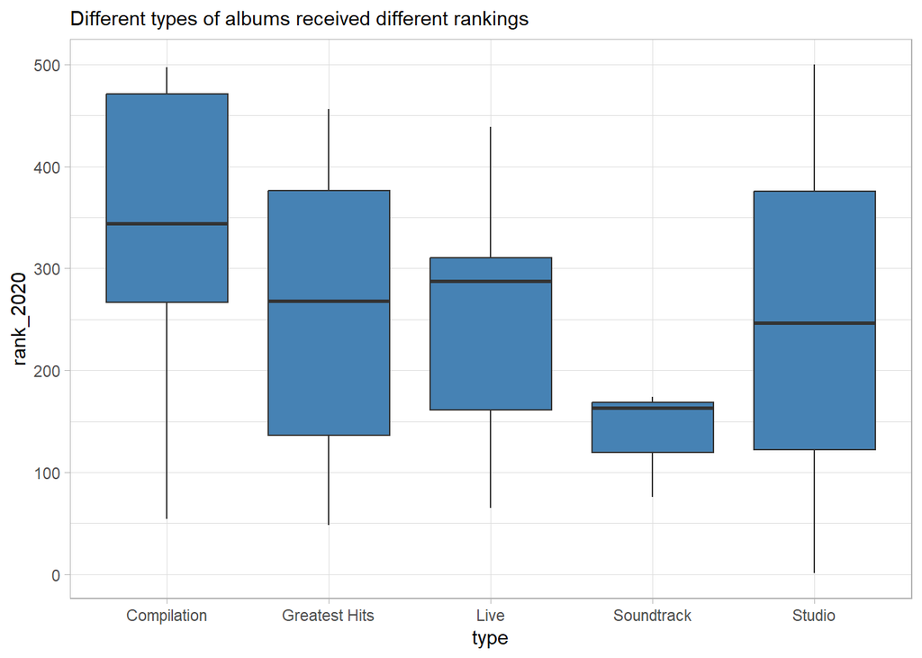

```r
#Different types of albums received different rankings
ggplot(rolling_stone, aes(x = type, y = rank_2020)) +
  geom_boxplot(fill='steelblue') +
  labs(subtitle = "Different types of albums received different rankings")
```

```r
#37 albums are not on Spotify
rolling_stone %>%
  filter(is.na(spotify_popularity)) %>%
  count()
```

```
## # A tibble: 1 × 1
##       n
##   <int>
## 1    37
```

```r
#191 albums did not receive a ranking on the 2020 list
rolling_stone %>%
  filter(is.na(rank_2020)) %>%
  count()
```

```
## # A tibble: 1 × 1
##       n
##   <int>
## 1   191
```

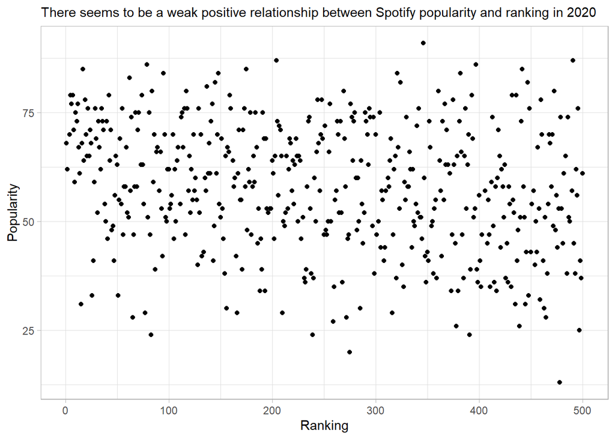

```r
#There seems to be a weak positive relationship between Spotify popularity and ranking in 2020
rolling_stone %>%
  filter(!(is.na(rank_2020)) & !(is.na(spotify_popularity))) %>%
  ggplot(aes(rank_2020, spotify_popularity)) +
  geom_point() +
  labs(subtitle = "There seems to be a weak positive relationship between Spotify popularity and ranking in 2020", x = "Ranking", y = "Popularity", fill = "Type")
```

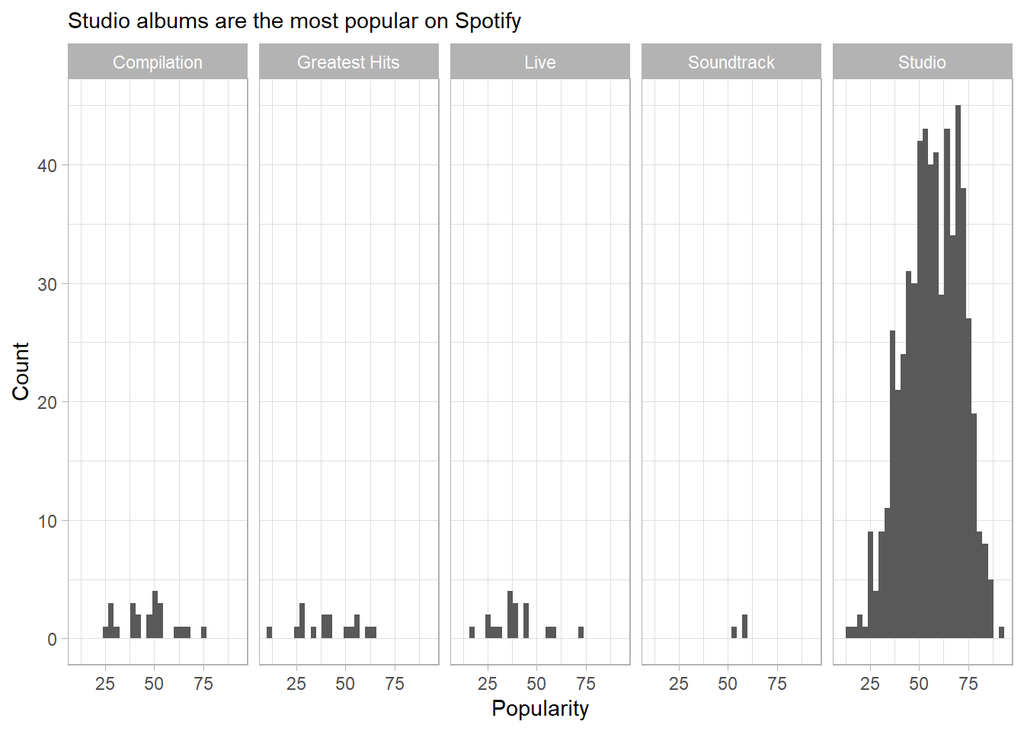

```r
#Studio albums seem to be the most popular on Spotify
ggplot(rolling_stone, aes(spotify_popularity)) +
  geom_histogram() +
  facet_grid(.~type) +
  labs(subtitle = "Studio albums are the most popular on Spotify", x = "Popularity", y = "Count")
```

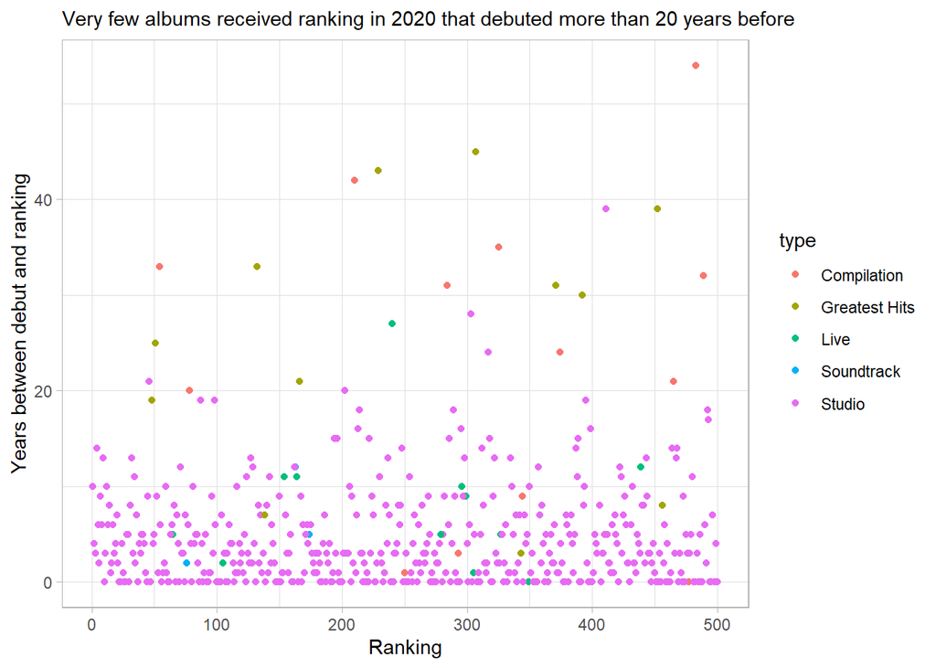

```r
#Very few albums received ranking in 2020 that debuted more than 20 years before - most of these were compilation or greatest hits albums
rolling_stone %>%
  filter(!(is.na(rank_2020))) %>%
  ggplot(aes(years_between, rank_2020, color = type)) +
  geom_point() +
  coord_flip() +
  labs(subtitle = "Very few albums received ranking in 2020 that debuted more than 20 years before", x = "Years between debut and ranking", y = "Ranking")
```

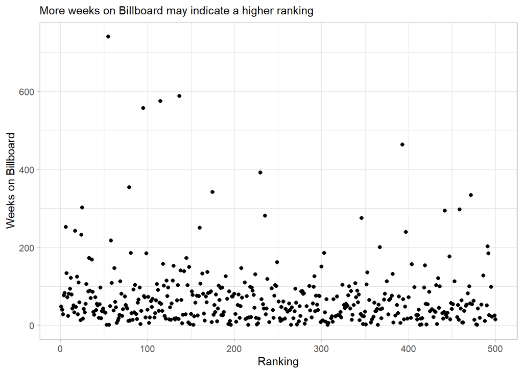

```r
#More weeks on Billboard may indicate a higher ranking
rolling_stone %>%
  filter(!(is.na(rank_2020) & !(is.na(weeks_on_billboard)))) %>%
  ggplot(aes(rank_2020, weeks_on_billboard)) +
  geom_point() +
  labs(subtitle = "More weeks on Billboard may indicate a higher ranking", x = "Ranking", y = "Weeks on Billboard")
```

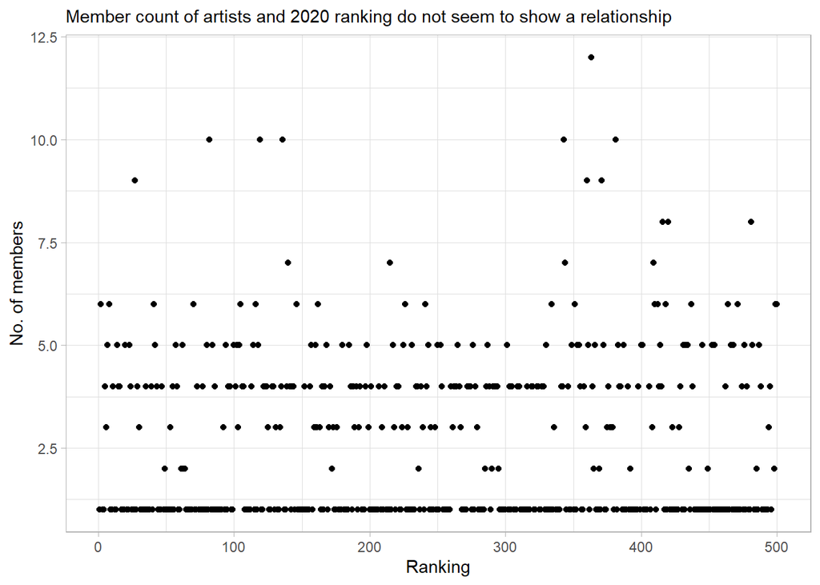

```r
#Member count of artists and 2020 ranking do not seem to show a relationship
rolling_stone %>%
  filter(!(is.na(rank_2020))) %>%
  ggplot(aes(rank_2020, artist_member_count)) +
  geom_point() +
  labs(subtitle = "Member count of artists and 2020 ranking do not seem to show a relationship", x = "Ranking", y = "No. of members")
```

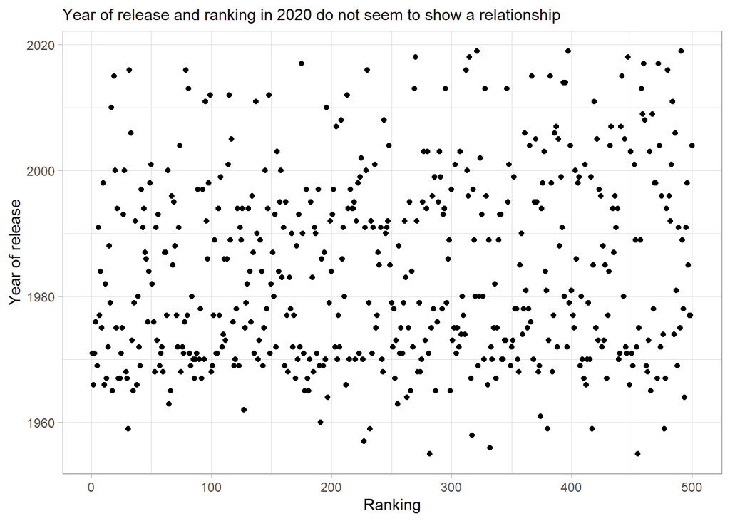

```r
#Year of release and ranking in 2020 do not seem to show a relationship
rolling_stone %>%
  filter(!(is.na(rank_2020))) %>%
  ggplot(aes(rank_2020, release_year)) +
  geom_point() +
  labs(subtitle = "Year of release and ranking in 2020 do not seem to show a relationship", x = "Ranking", y = "Year of release")
```

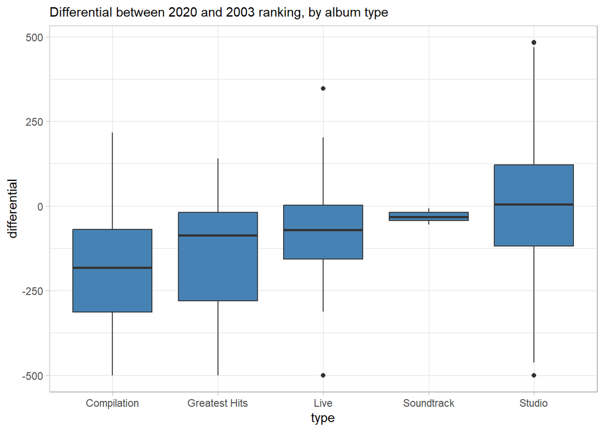

```r
#Differential between 2020 and 2003 ranking, by album type
ggplot(rolling_stone, aes(x = type, y = differential)) +
  geom_boxplot(fill='steelblue') +
  labs(subtitle = "Differential between 2020 and 2003 ranking, by album type")
```

## Data cleaning

```r
#Filter out 'Various Artists' rows, since they miss almost all data points
rs_df <- rolling_stone %>%
  filter(clean_name != "Various Artists")

#Change missing values in spotify_popularity and weeks_on_billboard to be able to use them in models
rs_df[is.na(rs_df$spotify_popularity), 'spotify_popularity'] <- 0
table(is.na(rs_df$spotify_popularity))
```

```
##
## FALSE
##   686
```

```r
rs_df[is.na(rs_df$weeks_on_billboard), 'weeks_on_billboard'] <- 0
table(is.na(rs_df$spotify_popularity))
```

```
##
## FALSE
##   686
```

```r
#Convert album type to factor to be able to use it in the regression model
rs_df$type <- as.factor(rs_df$type)
```

# Hypothesis 1

To test the first hypotheses, linear regression models will be fitted on the dataset to predict Top 500 ranking in 2020. Variables are not in the same units of measurement, so they will be scaled in both models.

Simple linear regression was used to test if Spotify popularity significantly predicted Top 500 ranking in 2020. The fitted regression model was: 2020 ranking = 0.02142 + -0.18014*Spotify popularity.

The regression model was statistically significant (R^2 = 0.02886, F = 15.77, p = 8.22e-05). Spotify popularity significantly predicted ranking in 2020 (B = -0.18014, p = 8.22e-05): higher Spotify popularity predicted a higher ranking (a lower value in ranking).

```r
#Build simpler model
model_s <- lm(scale(rank_2020) ~ scale(spotify_popularity), data = rs_df)
summary(model_s)
```

```
##
## Call:
## lm(formula = scale(rank_2020) ~ scale(spotify_popularity), data = rs_df)
##
## Residuals:
##      Min       1Q   Median       3Q      Max
## -2.24098 -0.84547 -0.05498  0.85081  1.97584
##
## Coefficients:
##                           Estimate Std. Error t value Pr(>|t|)
## (Intercept)                0.02142    0.04449   0.481     0.63
## scale(spotify_popularity) -0.18014    0.04537  -3.971 8.22e-05 ***
## ---
## Signif. codes:  0 '***' 0.001 '**' 0.01 '*' 0.05 '.' 0.1 ' ' 1
##
## Residual standard error: 0.9855 on 496 degrees of freedom
##   (188 observations deleted due to missingness)
## Multiple R-squared:  0.03081,    Adjusted R-squared:  0.02886
## F-statistic: 15.77 on 1 and 496 DF,  p-value: 8.22e-05
```

```r
confint(model_s)
```

```
##                                 2.5 %     97.5 %
## (Intercept)               -0.06598748  0.1088291
## scale(spotify_popularity) -0.26927696 -0.0910103
```

Checking model assumptions shows that assumptions are met: since there are no duplicates in the dataset, residuals are independent. There is a linear relationship between the predictor and the outcome variable. The normality plot shows acceptable normality of residuals. Homoscedasticity assumption is also met.

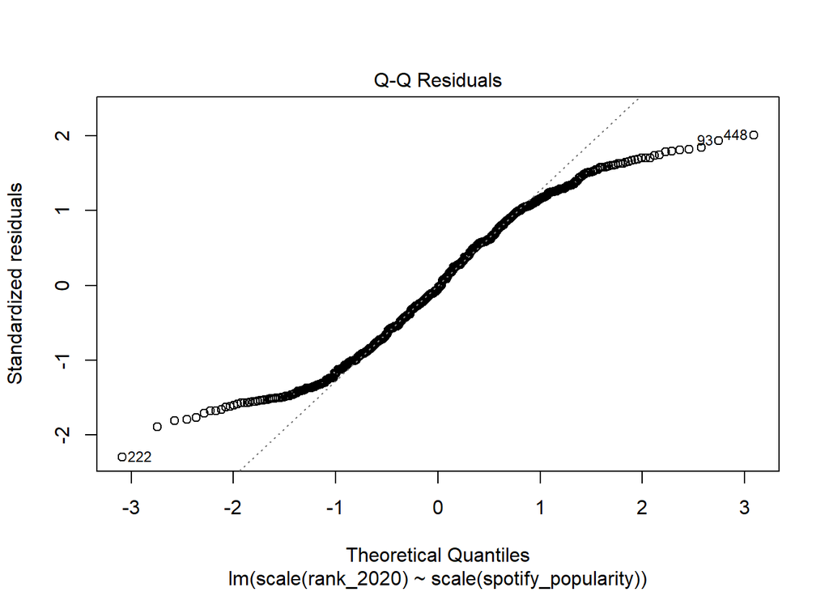

```r
#Normality
plot(model_s, 2)
```

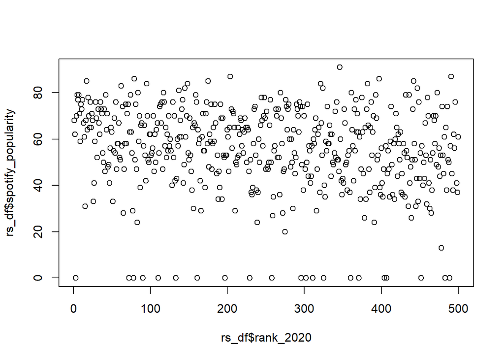

```r
#Linearity
plot(rs_df$rank_2020, rs_df$spotify_popularity)
```

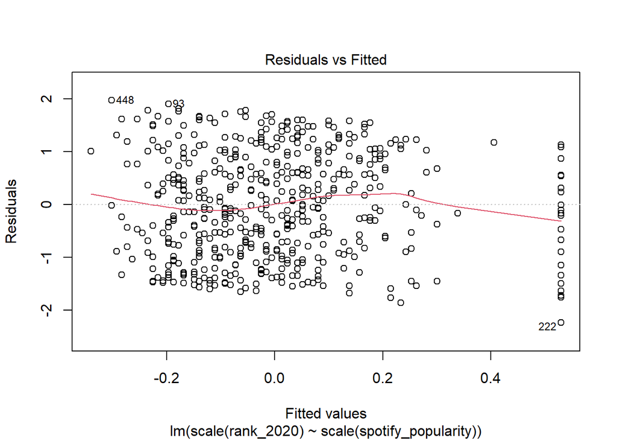

```r
#Homoscedasticity
plot(model_s, 1)
```

```r
#Build more complex model
model_c <- lm(scale(rank_2020) ~ scale(spotify_popularity) + scale(weeks_on_billboard) + scale(years_between) + scale(release_year) + type, data = rs_df)
summary(model_c)
```

```
##
## Call:
## lm(formula = scale(rank_2020) ~ scale(spotify_popularity) + scale(weeks_on_billboard) +
##     scale(years_between) + scale(release_year) + type, data = rs_df)
##
## Residuals:
##      Min       1Q   Median       3Q      Max
## -2.20062 -0.77876 -0.02912  0.79097  1.94581
##
## Coefficients:
##                           Estimate Std. Error t value Pr(>|t|)
## (Intercept)                0.23140    0.29851   0.775    0.439
## scale(spotify_popularity) -0.21329    0.05157  -4.136 4.16e-05 ***
## scale(weeks_on_billboard) -0.14092    0.04257  -3.311    0.001 ***
## scale(years_between)      -0.06252    0.06384  -0.979    0.328
## scale(release_year)        0.24032    0.04723   5.088 5.17e-07 ***
## typeGreatest Hits         -0.38843    0.38440  -1.010    0.313
## typeLive                  -0.25158    0.40057  -0.628    0.530
## typeSoundtrack            -0.79821    0.62989  -1.267    0.206
## typeStudio                -0.22074    0.30843  -0.716    0.475
## ---
## Signif. codes:  0 '***' 0.001 '**' 0.01 '*' 0.05 '.' 0.1 ' ' 1
##
## Residual standard error: 0.9592 on 489 degrees of freedom
##   (188 observations deleted due to missingness)
## Multiple R-squared:  0.09473,    Adjusted R-squared:  0.07992
## F-statistic: 6.396 on 8 and 489 DF,  p-value: 6.462e-08
```

```r
confint(model_c)
```

```
##                                2.5 %      97.5 %
## (Intercept)               -0.3551186  0.81791179
## scale(spotify_popularity) -0.3146139 -0.11196183
## scale(weeks_on_billboard) -0.2245612 -0.05728399
## scale(years_between)      -0.1879676  0.06291965
## scale(release_year)        0.1475160  0.33312268
## typeGreatest Hits         -1.1437014  0.36684855
## typeLive                  -1.0386325  0.53548180
## typeSoundtrack            -2.0358476  0.43942103
## typeStudio                -0.8267487  0.38527527
```

Checking model assumptions for the complex model also shows that assumptions are met. Normality of residuals is acceptable, homoscedasticity is also met, and there is no multicollinearity present.

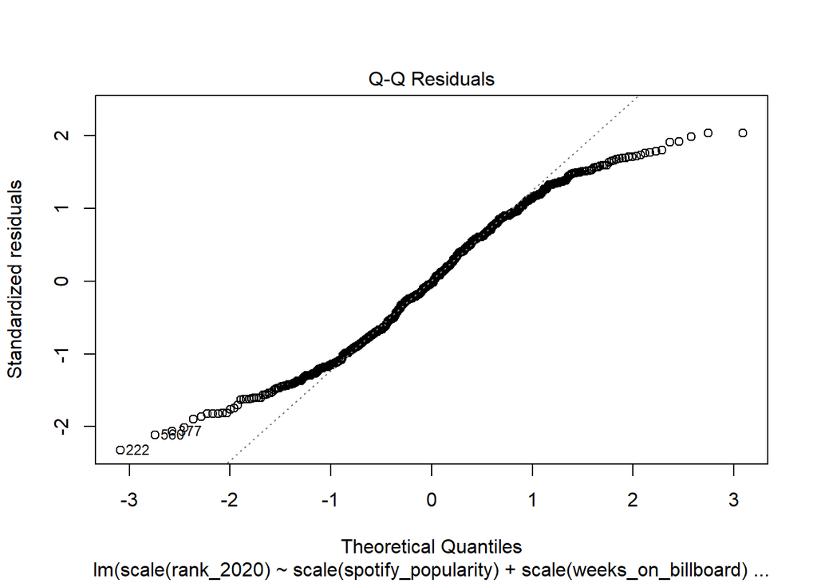

```r
#Normality
plot(model_c, 2)
```

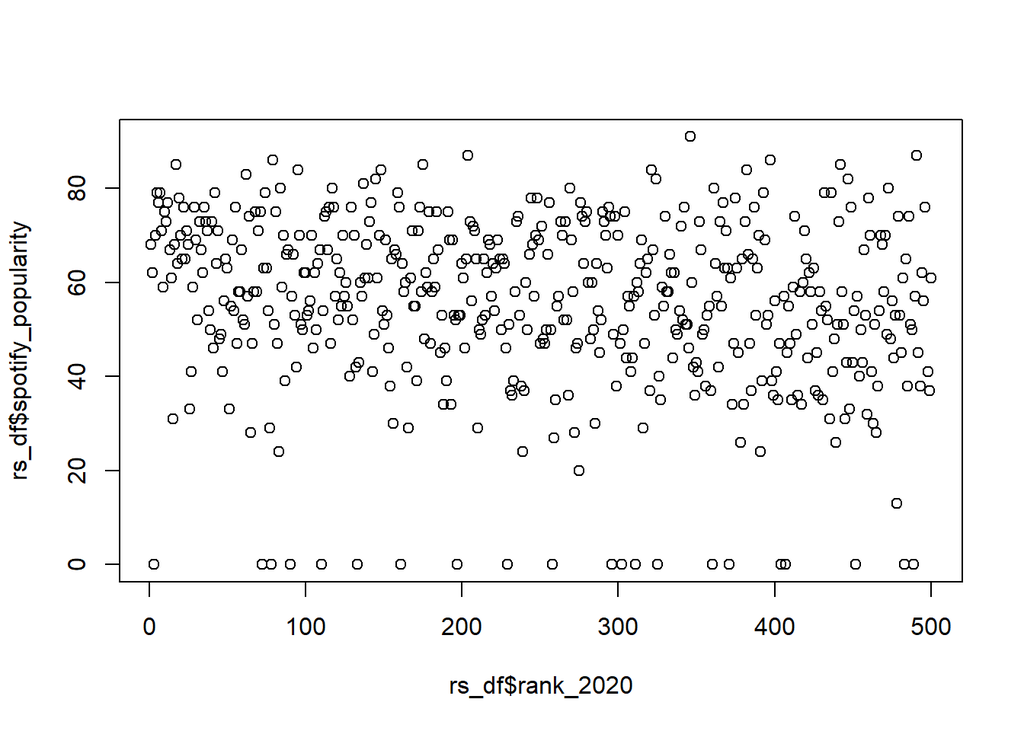

```r
#Linearity
plot(rs_df$rank_2020, rs_df$spotify_popularity)
```

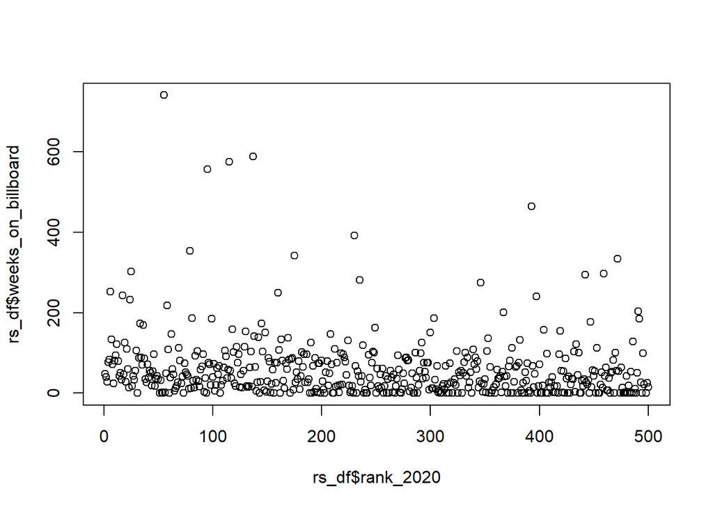

```r
plot(rs_df$rank_2020, rs_df$weeks_on_billboard)
```

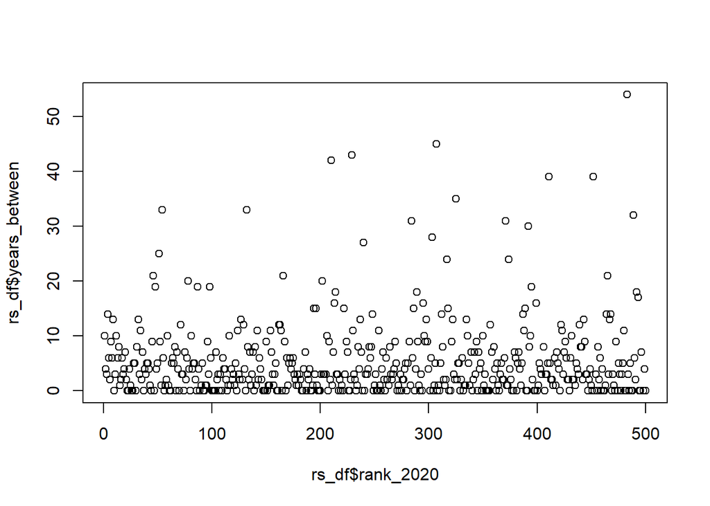

```r
plot(rs_df$rank_2020, rs_df$years_between)
```

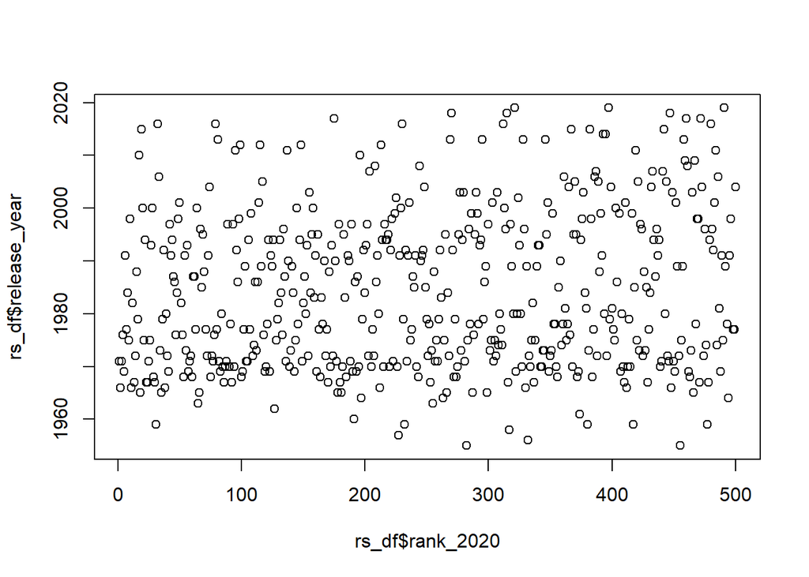

```r
plot(rs_df$rank_2020, rs_df$release_year)
```

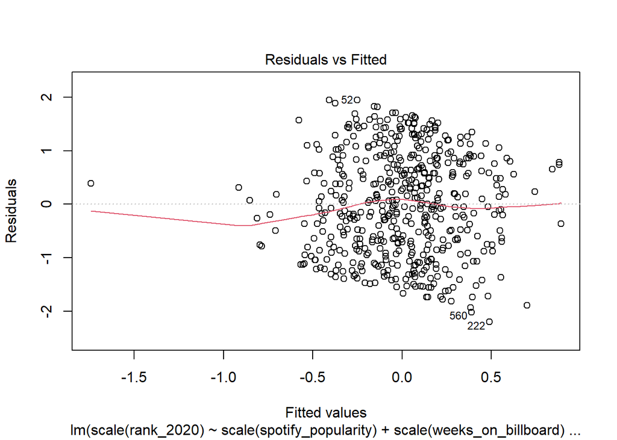

```r
#Homoscedasticity
plot(model_c, 1)
```

```r
#Multicollinearity
vif(model_c)
```

```
##                               GVIF Df GVIF^(1/(2*Df))
## scale(spotify_popularity) 1.363923  1        1.167871
## scale(weeks_on_billboard) 1.203739  1        1.097150
## scale(years_between)      1.678533  1        1.295582
## scale(release_year)       1.275039  1        1.129176
## type                      1.673394  4        1.066473
```

According to the comparison of the two models, the more complex model is a better fit (F = 4.9326, p = 2.106e-05). Akaike Information Criteria also shows that the more complex model is better (AIC = 1383.15). The more complex model explains 7.99% of the variance of the outcome variable, whereas the simpler model only explains 2.88%. Therefore, the inclusion of multiple predictors in the model was a reasonable choice.

```r
#Compare the two models
anova(model_s, model_c)
```

```
## Analysis of Variance Table
##
## Model 1: scale(rank_2020) ~ scale(spotify_popularity)
## Model 2: scale(rank_2020) ~ scale(spotify_popularity) + scale(weeks_on_billboard) +
##     scale(years_between) + scale(release_year) + type
##   Res.Df    RSS Df Sum of Sq      F    Pr(>F)
## 1    496 481.69
## 2    489 449.92  7    31.769 4.9326 2.106e-05 ***
## ---
## Signif. codes:  0 '***' 0.001 '**' 0.01 '*' 0.05 '.' 0.1 ' ' 1
```

```r
models <- list(model_s, model_c)
mod.names <- c('spot', 'spot.billb.yrsbetween.releaseyr.type')
aictab(cand.set = models, modnames = mod.names)
```

```
##
## Model selection based on AICc:
##
##                                       K    AICc Delta_AICc AICcWt Cum.Wt
## spot.billb.yrsbetween.releaseyr.type 10 1383.15       0.00      1      1
## spot                                  3 1402.73      19.57      0      1
##                                           LL
## spot.billb.yrsbetween.releaseyr.type -681.35
## spot                                 -698.34
```

# Hypothesis 2

Testing the effect of album type on ranking in 2020, a one-way analysis of variance model was fitted on the dataset to explore whether there was any statistical difference in Top 500 ranking in 2020 between album types.

The ANOVA model was not significant (p = 0.314). It can be concluded that album type did not influence Top 500 ranking in 2020.

```r
model_aov <- aov(rank_2020 ~ type, data = rs_df)
summary(model_aov)
```

```
##              Df   Sum Sq Mean Sq F value Pr(>F)
## type          4    98872   24718   1.191  0.314
## Residuals   493 10232798   20756
## 188 observations deleted due to missingness
```

The model did not meet assumptions: normality of residuals has been violated. Levene’s test shows that homogeneity of variance is met (F = 2.2382, p = 0.0639).

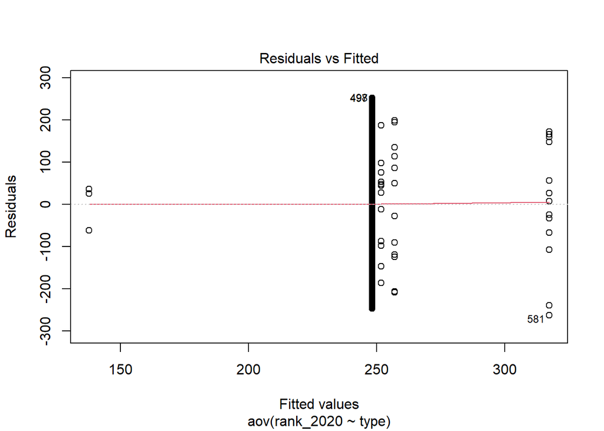

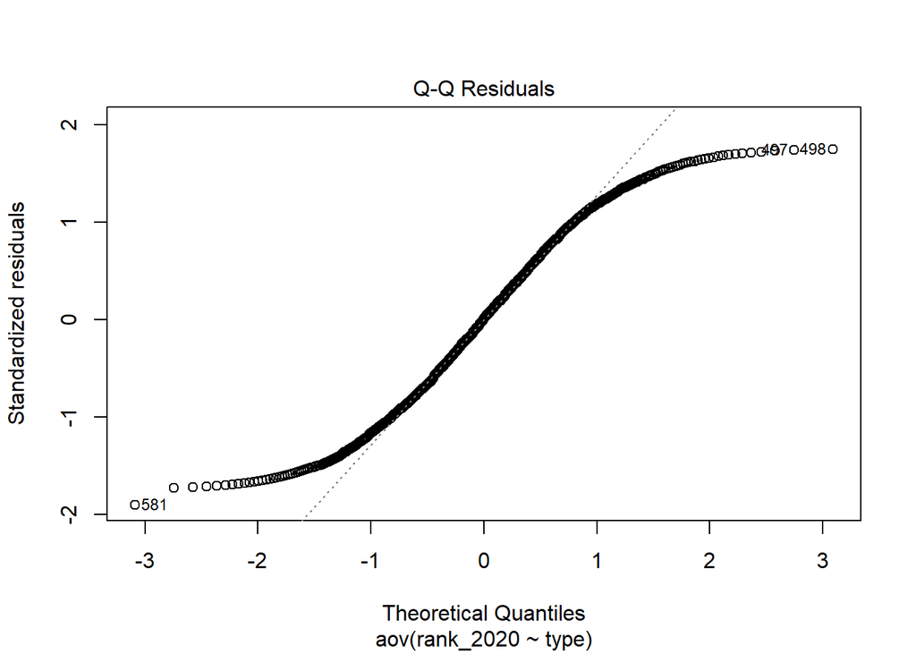

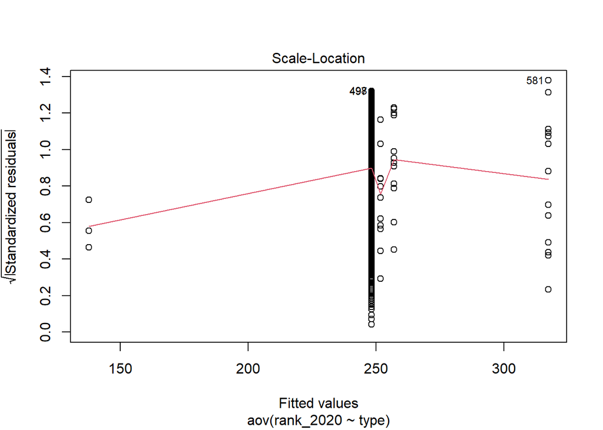

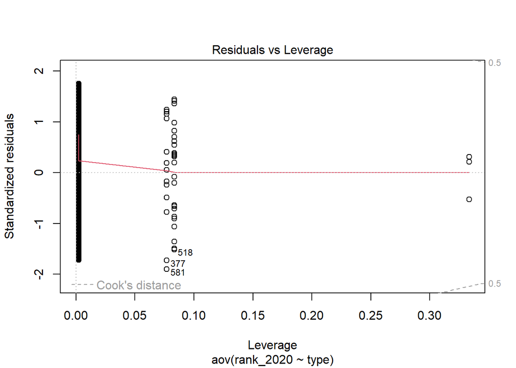

```r
plot(model_aov)
```

```r
leveneTest(rank_2020 ~ type, data = rs_df)
```

```
## Levene's Test for Homogeneity of Variance (center = median)
##        Df F value Pr(>F)
## group   4  2.2382 0.0639 .
##       493
## ---
## Signif. codes:  0 '***' 0.001 '**' 0.01 '*' 0.05 '.' 0.1 ' ' 1
```

# Hypothesis 3

One-way ANOVA was used to test whether album type influenced the ranking differential between 2020 and 2003. The model was significant (F = 11.01, p = 1.18e-08), meaning there is significant difference between different album types in terms of differential.

```r
model_diff <- aov(differential ~ type, data = rs_df)
summary(model_diff)
```

```
##              Df   Sum Sq Mean Sq F value   Pr(>F)
## type          4  1652599  413150   11.01 1.18e-08 ***
## Residuals   681 25561493   37535
## ---
## Signif. codes:  0 '***' 0.001 '**' 0.01 '*' 0.05 '.' 0.1 ' ' 1
```

Model assumptions were met: observations are independent, normality of residuals is acceptable and equality of variances is also met according to Levene’s test (F = 1.1507, p = 0.3316).

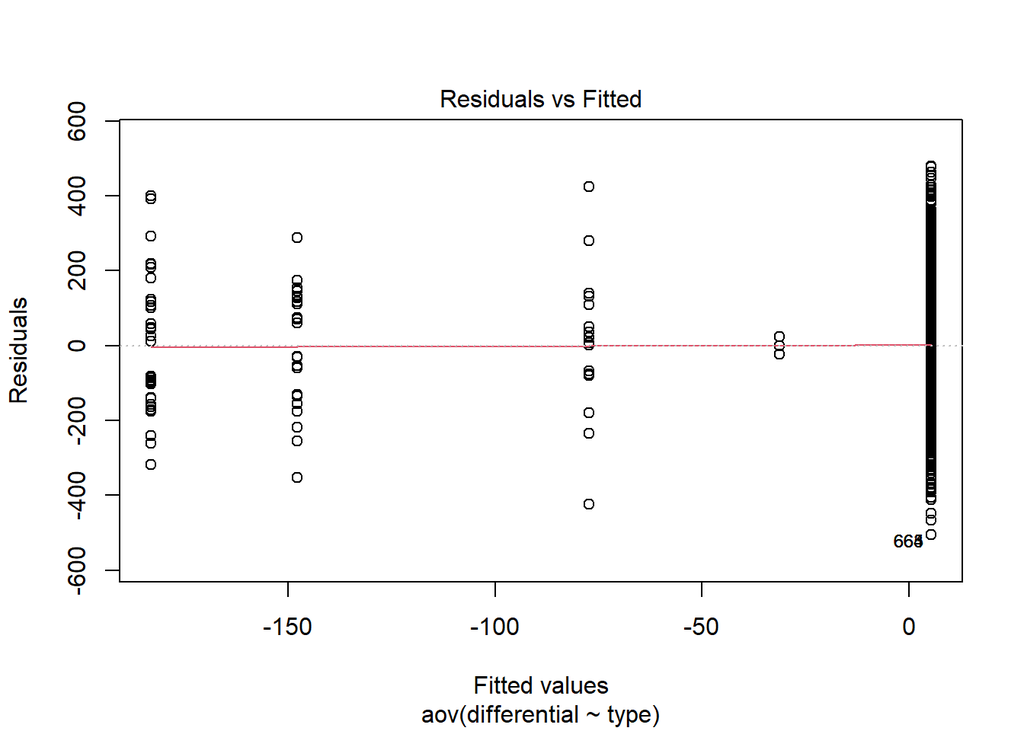

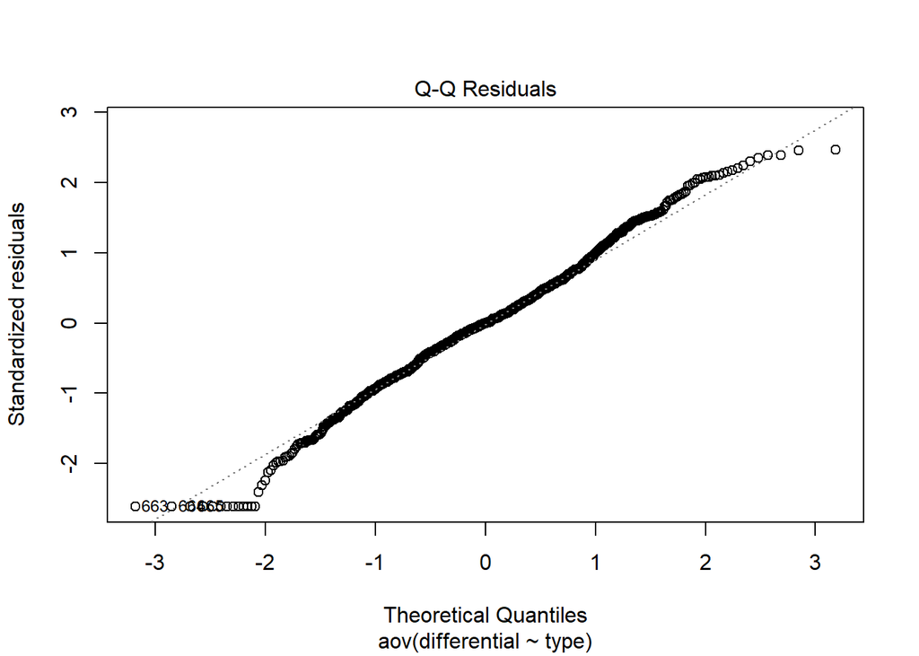

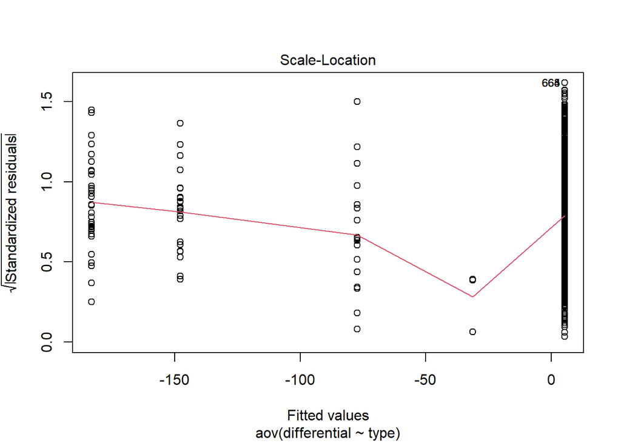

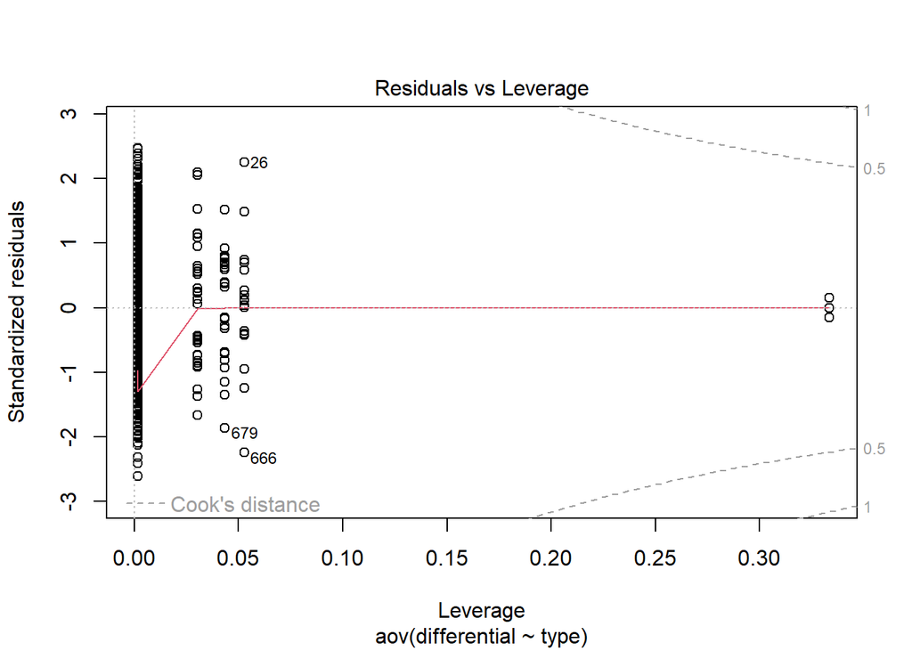

```r
plot(model_diff)
```

```r
leveneTest(differential ~ type, data = rs_df)
```

```
## Levene's Test for Homogeneity of Variance (center = median)
##        Df F value Pr(>F)
## group   4  1.1507 0.3316
##       681
```

According to post-hoc comparisons, there was a statistically significant difference in differential between Studio and Compilation (p = 7.5e-07), and Studio and Greatest Hits (p = 0.0022) album types.

```r
pairwise.t.test(rs_df$differential, rs_df$type, p.adj='bonferroni')
```

```
##
##  Pairwise comparisons using t tests with pooled SD
##
## data:  rs_df$differential and rs_df$type
##
##               Compilation Greatest Hits Live   Soundtrack
## Greatest Hits 1.0000      -             -      -
## Live          0.5835      1.0000        -      -
## Soundtrack    1.0000      1.0000        1.0000 -
## Studio        7.5e-07     0.0022        0.6798 1.0000
##
## P value adjustment method: bonferroni
```

## Discussion

On a dataset of albums appearing in the Rolling Stones’ ‘Top 500 Greatest Albums of All Time’ list, I examined what aspects contributed to an album appearing in the 2020 Top 500 ranking, and what difference album type made in rankings.

Regression models were used to analyze the effect of predictor variables, such as Spotify popularity of an album, weeks spent on Billboard, years between debut and Top 500 ranking, album release year and album type, on outcome variable 2020 ranking. According to my analyses, higher Spotify popularity and more weeks spent on Billboard affected rankings positively, whereas a more recent release year predicted lower ranking on the Top 500.

These results may indicate that in 2020, albums that were available and more popular on Spotify led to a higher ranking. This result seems evident, since Spotify took over physical CD copies and even radio play numbers, therefore an album not available on Spotify might be found less frequently by listeners, and therefore might be less popular among consumers. Also, weeks spent on Billboard indicate the number of radio plays of a certain album. Albums that could hold their place on the Billboard were played more frequently on radios, therefore they may have gained more popularity which also may have resulted in their rise of popularity on Spotify. However, this relationship would have to be investigated in another analysis. Finally, release year may have contributed to rankings in 2020 in a way, that albums released earlier have been on the radar of music critiques and experts for longer, therefore they have had more chance of rising to the top of The 500 list, as opposed to albums that have most recently been released. With the exception of a number of extraordinary successes, most ‘young’ albums only received a lower ranking, indicating that they have made less impact than ‘older’, ‘classic’ albums.

The analysis of variance on the effect of album types on ranking in 2020 did not yield a significant result, which indicates that 2020 rankings did not differ between album types. In other words, album type was not an aspect that influenced ranks in 2020.

However, album type did influence differential between 2020 and 2003 rankings. More specifically, Studio albums received significantly different rankings than Greatest Hits and Compilation albums. This might be because Greatest Hits and Compilation albums were more popular when physical copies of albums were sold, since they compiled an artists’ most popular tracks. With the rise of streaming services, such as Spotify or Amazon Music, the need for these compilation albums may have dropped, since with a single monthly subscription price, all musical work of an artist has become available for listeners. Also the intelligent algorithm of these streaming services creates various playlists for anyone to listen to, that also include favourites, most popular tracks by artists, and new releases. Therefore, independent record labels and artists no longer need to create these albums by themselves, they can rely on streaming services to provide these playlists. This phenomena may be the reason that Greatest Hits and Compilation albums received lower rankings over time, compared to Studio albums.

All in all, it can be concluded that technological advancements influence the music industry in ways they could not have been imagined back in the early 2000’s. Availability and variety of musical pieces that can be accessed by anyone in the world has risen greatly during the past two decades. Just take Hungary as an example: back in the times of socialism, all music from the ‘West’ was banned, and the Hungarian popular music industry was ruled by strict government rules (https://zti.hu/mza/m0403.htm). Almost 40 years later, even if we have not payed a single penny, we can access virtually any music via YouTube, and if we pay a subscription fee to Spotify, YouTube Music or Amazon Music, we can listen to anything our heart desires. New genres have also risen because musical instruments and composing methods have also gone through tremendous advancement.

Overall, some interesting differences can be found over time in the Rolling Stones’ Top 500 lists as well, which makes it extremely difficult to compare albums from the 1950’s to albums from 2019. This raises the question: what aspects make a musical piece popular, in other words, ‘great’ nowadays? How have these aspects changed, which ones are still relevant? Do we even need these rankings, or shall we introduce different ways to quantify the success of an album? Future research is needed to answer these questions better.